# Exploratory Phase

First, I’ll begin by setting up any packages I need and clearing R’s brain.

```r
rm(list = ls())
library(here)
library(tidyverse)
library(ggfortify)
```

Now, to import my data, ensuring that I turn on “stringsAsFactors=TRUE”

```r
Bacteria_Data <- read.csv(here("Data", "AS-Raw-Data-Indicator-bacteria-project.csv"), stringsAsFactors=TRUE)
```

The first variable I’ll work with is pH. Using a histogram, I can search for outliers and get a better idea of how my data looks.

```r
ggplot(Bacteria_Data, aes(x=pH)) +
  geom_histogram()

## This data looks pretty consistent within a certain range. However, there may be a couple of  outliers on the lower end of the scale.
```

[output not shown]

Now, I’ll look at Temperature using another histogram.

```r
ggplot(Bacteria_Data, aes(x=Temperature)) +
  geom_histogram()

## Again, this data looks pretty consistent. On the higher end of the range, there could be some outliers to look out for.
```

[output not shown]

For my last variable, I’ll look at total coliform count.

```r
ggplot(Bacteria_Data, aes(x=Coliform_MPN)) +
  geom_histogram()

##Things are pretty consistent here besides a major outlier I can identify. That one's at around 80,000 MPN and could carry some high leverage.
```

[output not shown]

Next, to get an overall summary of my data for assessment of all variables and their statistics.

```r
summary(Bacteria_Data)

## The summary() function shows important information about data such as min, max, and quartiles. This is useful in assessing the quality of data, and also determining if there are any NA's in a larger data set. I'm noticing that there are some NA values, and that max values are very different from means in some variables, such as coliform count (nearly 60,000 MPN difference). Things like this should be taken into account when searching for potential outliers.
```

[output not shown]

I’ll make a scatterplot of temperature vs. Coliform count from all samples. This will allow me to make assumptions about their relationship outside of my prior research.

```r
ggplot(Bacteria_Data, aes(x=Temperature, y=Coliform_MPN)) +
  geom_point() +
  theme_bw()

## Temperature will show up on my x-axis, and coliform count will be my y-axis. I find this the most appropriate for visualization of data, as we see coliform data increase or decrease along temperature increase.
```

[output not shown]

For these next couple of steps, I’ll go above data exploration into attempting some tests. I had already written out this code, so I’ll stick with it rather than deleting it. I’ve done this for all variables in my data set that I’m analyzing.

Now, I’ll create a new data set which solely relates temperature to coliform count. This will follow the linear regression model of data analysis.

```r
Temperature_mod <- lm(Temperature ~ Coliform_MPN, data=Bacteria_Data)

## This sets us up to use autoplot().
```

autoplot() will demonstrate different distributions of the data. When using linear regression, we’re assuming that we have evenly distributed data and equal distances between points and a line.

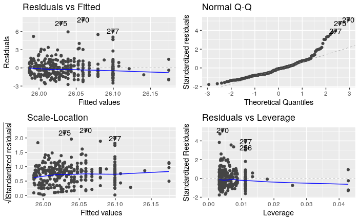

```r
autoplot(Temperature_mod)
```

The anova test will determine whether or not the relationship between my two variables is significant or not. A p-value less than 0.05 indicates a significant relationship.

```r
anova(Temperature_mod)

## This data set includes outliers which I've identified. I believe that this will impact p-value, so I'll remove them in a later step to see if it changes.
```

[output not shown]

A p-value of 0.6593 is far from significant, meaning that from this data in its current state, temperature is not a good indication of total coliform count.

Now, to repeat this process with pH instead. I’ll attempt to demonstrate the relationship between pH and total coliform count within samples. First to make a scatterplot of pH vs. coliform count.

```r
ggplot(Bacteria_Data, aes(x=pH, y=Coliform_MPN)) +
  geom_point()+
  theme_bw()
```

[output not shown]

Now to create a new model for analyzing solely pH and coliform count.

```r
pH_mod <- lm(pH ~ Coliform_MPN, data=Bacteria_Data)
```

Time to autoplot this new dataset.

```r
autoplot(pH_mod)
```

[output not shown]

Again, I’ll use anova to test the relationship between my two variables, this time pH and coliform count.

```r
anova(pH_mod)
```

[output not shown]

This test demonstrates that the relationship between pH and coliform count is not significant, with a p-value of .5298. However, the relationship between pH and coliform count is more significant than that of temperature and coliform count.

As relationships between coliform count and pH/temperature are not significant, I decided to test the relationship of these two variables with E. coli specifically. E. coli is a type of coliform, however, this new data will be specified for it only. Some of my research surrounding temperature and pH related to E. coli, so I’m hoping that these relationships appear more significant.

First, to make a histogram of E. coli counts.

```r
ggplot(Bacteria_Data, aes(x=Ecoli_MPN))+
  geom_histogram()
```

[output not shown]

Now, I’ll make a scatterplot depicting the relationship between E. coli count and temperature.

```r
ggplot(Bacteria_Data, aes(x=Temperature, y=Ecoli_MPN)) +
         geom_point()+
         theme_bw()
```

[output not shown]